# 客户流失预警分析

DWB

2020/10/29

### $\textbf{·}$ 数据读入

将训练数据集sampledata.csv与测试数据集predata.csv读入，并将其中的变化率乘100，变为百分数：

```r
setwd("E:\\大学\\课程\\专业必修\\大三上\\统计机器学习\\HW\\HW4\\客户流失预警分析")
sample.data <- read.csv(file="sampledata.csv", header=T)
sample.data$chgdegree <- 100*sample.data$chgdegree
sample.data$chgexpense <- 100*sample.data$chgexpense
test.data <- read.csv(file="preddata.csv", header=T)
test.data$chgdegree <- 100*test.data$chgdegree
test.data$chgexpense <- 100*test.data$chgexpense
```

### $\textbf{·}$ 因变量和各自变量的箱线图

首先以是否违约作为分类标准，分别创建每个自变量关于因变量的箱线图并储存：

```r
library(ggplot2)
library(grid)
pic1 <- ggplot(sample.data, aes(group = churn, x=churn, y=tenure)) +
  geom_boxplot(fill = c('#FFB6C1', '#00FFFF')) + labs(title="在网时长-是否流失箱线图", x="是否流失", y = "在网时长(天)")
pic2 <- ggplot(sample.data, aes(group = churn, x=churn, y=expense)) +
  geom_boxplot(fill = c('#FFB6C1', '#00FFFF')) + labs(title="当月花费-是否流失箱线图", x="是否流失", y = "当月花费(元)")
pic3 <- ggplot(sample.data, aes(group = churn, x=churn, y=degree)) +
  geom_boxplot(fill = c('#FFB6C1', '#00FFFF')) + labs(title="个体度-是否流失箱线图", x="是否流失", y = "个体度(人数)")
pic4 <- ggplot(sample.data, aes(group = churn, x=churn, y=tightness)) +
  geom_boxplot(fill = c('#FFB6C1', '#00FFFF')) + labs(title="联系强度-是否流失箱线图", x="是否流失", y = "联系强度(分钟/人)")
pic5 <- ggplot(sample.data, aes(group = churn, x=churn, y=entropy)) +
  geom_boxplot(fill = c('#FFB6C1', '#00FFFF')) + labs(title="个体信息熵-是否流失箱线图", x="是否流失", y = "个体信息熵")
pic6 <- ggplot(sample.data, aes(group = churn, x=churn, y=(chgdegree))) +
  geom_boxplot(fill = c('#FFB6C1', '#00FFFF')) + labs(title="个体度变化-是否流失箱线图", x="是否流失", y = "个体度变化(%)")
pic7 <- ggplot(sample.data, aes(group = churn, x=churn, y=(chgexpense))) +
  geom_boxplot(fill = c('#FFB6C1', '#00FFFF')) + labs(title="花费变化-是否流失箱线图", x="是否流失", y = "花费变化(%)")
```

将这些箱线图绘制如下：

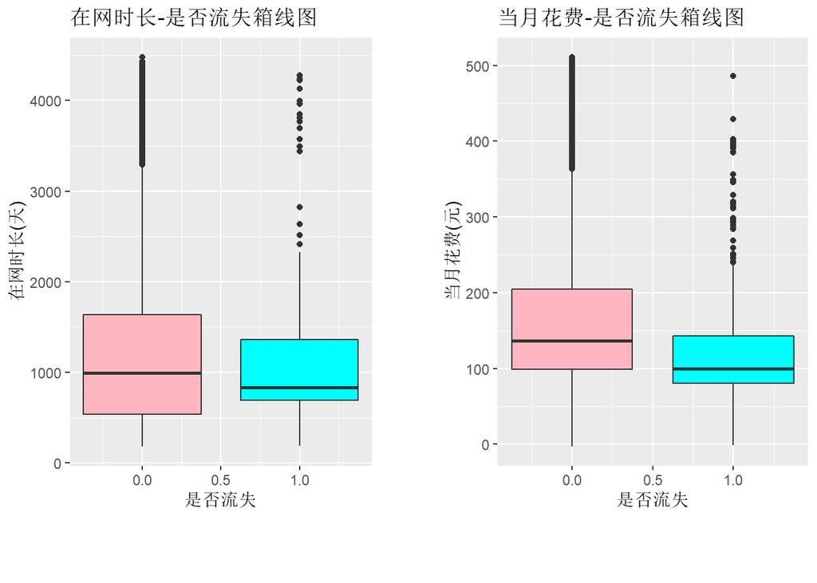

```r
grid.newpage()
pushViewport(viewport(layout = grid.layout(9,15)))
vplayout <- function(x,y){
  viewport(layout.pos.row = x, layout.pos.col = y)
}
print(pic1, vp = vplayout(1:8,1:7))
print(pic2, vp = vplayout(1:8,9:15))
```

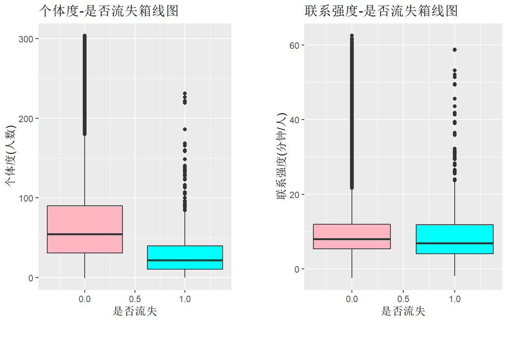

```r
grid.newpage()
pushViewport(viewport(layout = grid.layout(9,15)))
vplayout <- function(x,y){
  viewport(layout.pos.row = x, layout.pos.col = y)
}
print(pic3, vp = vplayout(1:8,1:7))
print(pic4, vp = vplayout(1:8,9:15))
```

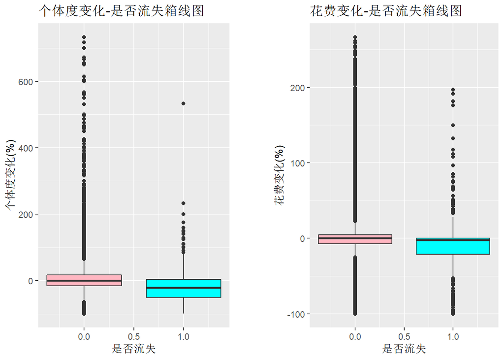

```r
grid.newpage()
pushViewport(viewport(layout = grid.layout(9,15)))
vplayout <- function(x,y){
  viewport(layout.pos.row = x, layout.pos.col = y)
}
print(pic6, vp = vplayout(1:9,1:7))
print(pic7, vp = vplayout(1:9,9:15))
```

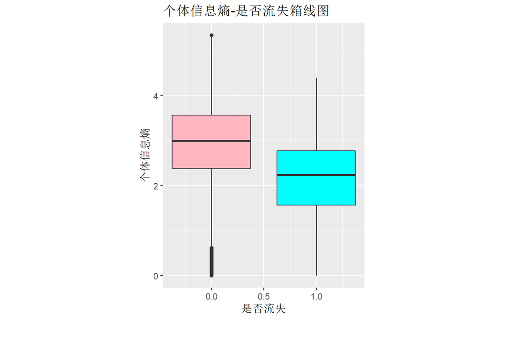

```r
grid.newpage()
pushViewport(viewport(layout = grid.layout(9,15)))
vplayout <- function(x,y){
  viewport(layout.pos.row = x, layout.pos.col = y)
}
print(pic5, vp = vplayout(1:8,5:11))
```

可以看到，相比于没有流失的客户，那些流失的客户相对有着平均较低的在网时间，更低的当月花费，更低的个体度（联系人数量）及信息熵；并且流失的客户相比之下，有着个体度（联系人数量）变少、花费变少的特点，在联系强度方面，差异并不显著。

### $\textbf{·}$ 变量标准化与模型建立

首先，将训练集数据的自变量进行标准化处理如下，使其样本均值为0，样本方差为1：

```r
sample.data$tenure <- scale(sample.data$tenure)
sample.data$expense <- scale(sample.data$expense)
sample.data$degree <- scale(sample.data$degree)
sample.data$tightness <- scale(sample.data$tightness)
sample.data$entropy <- scale(sample.data$entropy)
sample.data$chgdegree <- scale(sample.data$chgdegree)
sample.data$chgexpense <- scale(sample.data$chgexpense)
```

构建模型并查看如下：

```r
model <- glm(churn ~ tenure + expense + degree  + entropy + tightness + chgdegree + chgexpense,
            family = "binomial", data = sample.data)
summary(model)
```

```
##
## Call:
## glm(formula = churn ~ tenure + expense + degree + entropy + tightness +
##     chgdegree + chgexpense, family = "binomial", data = sample.data)
##
## Deviance Residuals:
##     Min       1Q   Median       3Q      Max
## -0.9051  -0.1756  -0.1203  -0.0749   4.1832
##
## Coefficients:
##             Estimate Std. Error z value Pr(>|z|)
## (Intercept) -5.04338    0.07162 -70.422  < 2e-16 ***
## tenure      -0.22605    0.05931  -3.811 0.000138 ***
## expense     -0.29249    0.05880  -4.974 6.56e-07 ***
## degree      -0.74134    0.13023  -5.693 1.25e-08 ***
## entropy     -0.34940    0.07039  -4.963 6.92e-07 ***
## tightness   -0.22344    0.04160  -5.371 7.82e-08 ***
## chgdegree   -0.37741    0.05150  -7.329 2.32e-13 ***
## chgexpense  -0.19658    0.04833  -4.067 4.75e-05 ***
## ---
## Signif. codes:  0 '***' 0.001 '**' 0.01 '*' 0.05 '.' 0.1 ' ' 1
##
## (Dispersion parameter for binomial family taken to be 1)
##
##     Null deviance: 6600.4  on 48392  degrees of freedom
## Residual deviance: 5842.9  on 48385  degrees of freedom
## AIC: 5858.9
##
## Number of Fisher Scoring iterations: 8
```

系数可以由柱状图展示如下：

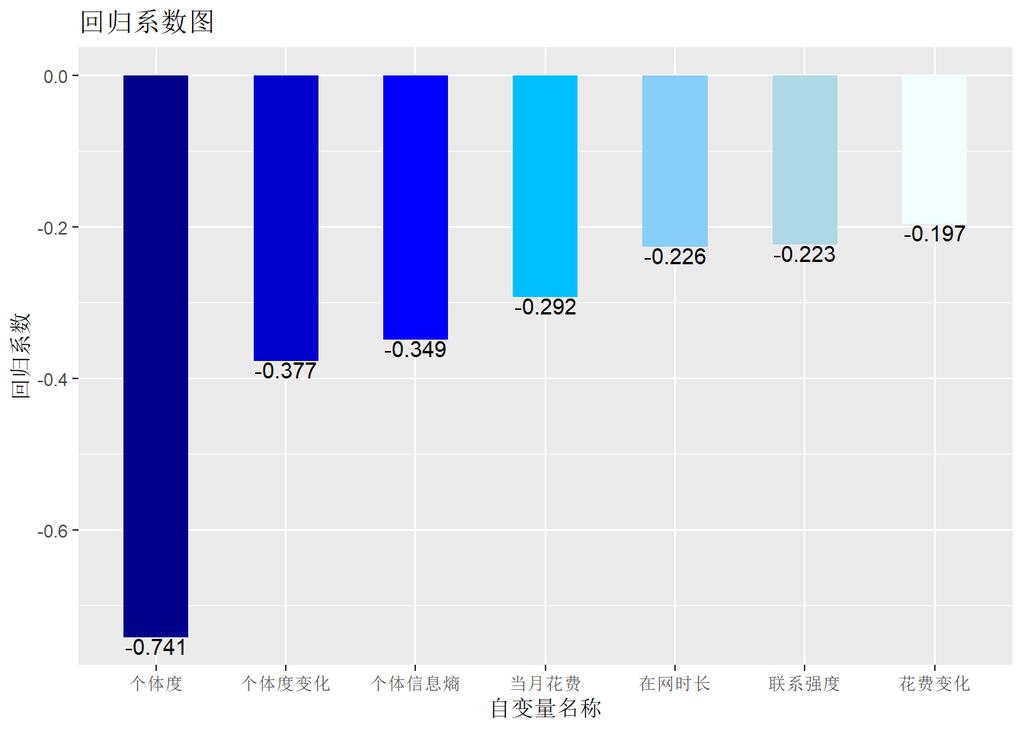

首先从回归结果的汇总来看，所有的自变量均有很小的p值，另外由于各自变量均已标准化，因此由上图可以看到，所有的自变量均为负数，可以理解为：个体度越大、个体度正向变化越大、个体信息熵越大、当月花费越大、在网时长越长、联系强度越高、花费正向变化越大的个体，越不容易流失；且个体度对是否流失影响最大。

### $\textbf{·}$ 使用模型进行预测

使用上述模型对训练集数据进行预测，因为样本正、反例不均衡，由$\frac{r}{1-r}=\frac{m^+}{m^-}$，知我们可以将设阈值设置为$r=\frac{m^+}{m^++m^-}$。

```r
m0 <- as.integer(table(sample.data$churn)[1])
m1 <- as.integer(table(sample.data$churn)[2])
r <- m1/(m1 + m0)
```

#### $\textbf{·}$ 模型对训练集数据的预测

使用模型对训练集数据预测如下：

```r
prob1 <- predict(object = model, newdata = sample.data, type = "response")
pred1 <- ifelse(prob1 >= r, "yes", "no")
pred1 <- factor(pred1, levels = c("yes","no"), order=TRUE)
table(sample.data$churn, pred1)
```

```
##    pred1
##       yes    no
##   0 14919 32858
##   1   441   175
```

可以将结果以下表展示：

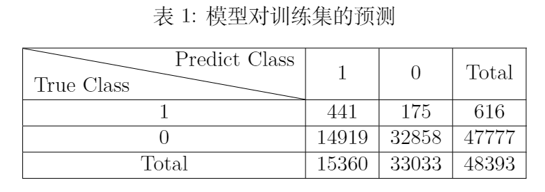

可以算得在训练集上，模型的预测精度为$Accuarancy = \frac{441+32858}{48393}=68.81\%$，查准率$Precision =$ $\frac{441}{15360}=2.87\%$，查全率$Recall = \frac{441}{616}=71.59\%$。因为该预测更关心查全率，因此可以知道，查全率($Recall$)更为重要，而对于那些错分的 $False Positive$，很可能是因为这些客户也在将要流失的边缘。因此可以认为，模型取得了不错的预测效果。

#### $\textbf{·}$ 模型对测试集数据的预测

首先，将测试集数据的所有自变量进行与训练集数据相同的标准化，使其样本均值为0，样本方差为1：

```r
test.data$tenure <- scale(test.data$tenure)
test.data$expense <- scale(test.data$expense)
test.data$degree <- scale(test.data$degree)
test.data$tightness <- scale(test.data$tightness)
test.data$entropy <- scale(test.data$entropy)
test.data$chgdegree <- scale(test.data$chgdegree)
test.data$chgexpense <- scale(test.data$chgexpense)
```

使用模型对测试集数据预测如下：

```r
prob2 <- predict(object = model, newdata = test.data, type = "response")
pred2 <- ifelse(prob2 >= r,"yes","no")
pred2 <- factor(pred2,levels = c("yes","no"),order=TRUE)
table(test.data$churn, pred2)
```

```
##    pred2
##       yes    no
##   0 14686 32521
##   1   510   183
```

可以将结果以下表展示：

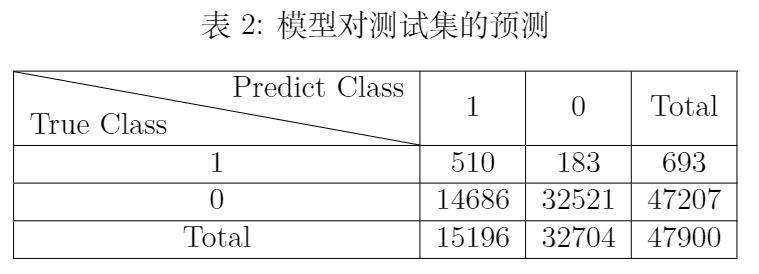

可以算得在测试集上，模型的预测精度为$Accuarancy = \frac{510+32521}{47900}=68.96\%$，查准率$Precision =$ $\frac{510}{15196}=3.36\%$，查全率$Recall = \frac{510}{693}=73.59\%$。同理在测试数据集上，查全率($Recall$)也较高，可以认为模型在测试集上也取得了不错的预测效果，没有出现严重的过拟合现象。

### $\textbf{·}$ ROC曲线与相应的AUC值

#### $\textbf{·}$ 训练集数据

上述模型在训练集数据上的ROC曲线与AUC值如下所示：

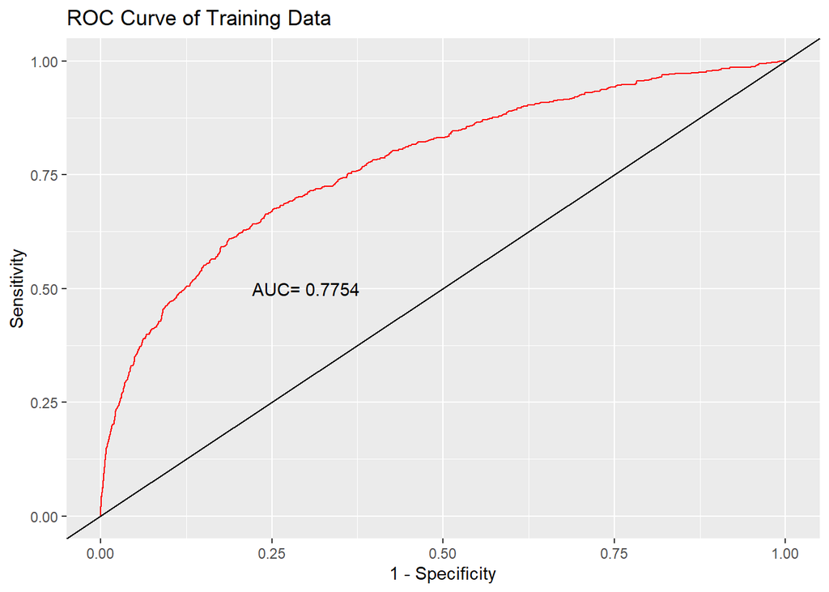

```r
library(pROC)
roc_curve <- roc(sample.data$churn, prob1)
x1 <- 1 - roc_curve$specificities
y1 <- roc_curve$sensitivities

ggplot(mapping = aes(x = x1, y = y1)) + geom_line(colour = 'red') + geom_abline(intercept = 0, slope = 1) +
  annotate('text', x = 0.3, y = 0.5, label = paste('AUC=', round(roc_curve$auc,4))) +
  labs(x = '1 - Specificity',y = 'Sensitivity', title = 'ROC Curve of Training Data')
```

可以看到在训练数据集上，AUC曲线显著高于$y=x$直线，并且可以算得$AUC$的值为0.7754，说明该模型拥有不错的预测效果。

#### $\textbf{·}$ 测试集数据

上述模型在测试集数据上的ROC曲线与AUC值如下所示：

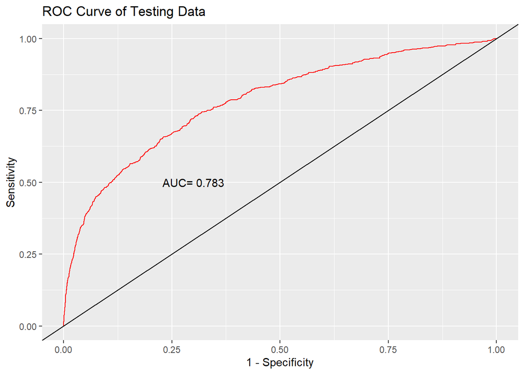

```r
library(pROC)
roc_curve <- roc(test.data$churn, prob2)
x2 <- 1 - roc_curve$specificities
y2 <- roc_curve$sensitivities

ggplot(mapping = aes(x = x2, y = y2)) + geom_line(colour = 'red') + geom_abline(intercept = 0, slope = 1) +
  annotate('text', x = 0.3, y = 0.5, label = paste('AUC=', round(roc_curve$auc,4))) +
  labs(x = '1 - Specificity',y = 'Sensitivity', title = 'ROC Curve of Testing Data')
```

可以看到在测试数据集上，AUC曲线依然显著高于$y=x$直线，并且可以算得$AUC$的值为0.7830，甚至高于在训练集上的表现。该模型在测试集上依然拥有不错的预测效果，说明我们得到的模型并没有出现过拟合现象。